# SING Bioinformatics Workshop - Part 1

Authors

Affiliation

Murray Cadzow

University of Otago

Pascale Lubbe

University of Otago

## Setup and Environment (10 min)

**Workshop**

The code that created this workshop can be found at https://github.com/murraycadzow/sing_guam and contains a script that will help recreate the workshop in a Unix environment outside of the Otago OnDemand system used at SING Micronesia.

Below is a schematic of the structure of the workshop files and directories (folders)

**Directory structure**

```
sing_guam/
├── aligned
│   ├── rs2231142_het_example.bam
│   ├── rs2231142_het_example.bam.bai
│   ├── rs2231142_hom_alt_example.bam
│   ├── rs2231142_hom_alt_example.bam.bai
│   ├── rs2231142_hom_ref_example.bam
│   └── rs2231142_hom_ref_example.bam.bai
├── fastq
│   ├── example.R1.fastq
│   └── example.R2.fastq
├── getting_started.html
├── getting_started.qmd
├── load_software.sh
├── pca
│   ├── 1kgp_allchr.indep_snp.pca.evec.tsv
│   └── 1kgp-phase3-samples.txt
├── ref
│   ├── human_g1k_v37.fasta
│   ├── human_g1k_v37.fasta.amb
│   ├── human_g1k_v37.fasta.ann
│   ├── human_g1k_v37.fasta.bwt
│   ├── human_g1k_v37.fasta.pac
│   └── human_g1k_v37.fasta.sa
├── sing_guam.Rproj
├── vcf
│   ├── 1kgp.chrMT.vcf.gz
│   ├── 1kgp.chrMT.vcf.gz.tbi
│   ├── 1kgp-phase3-samples.txt
│   └── example.3_sample.vcf
├── workshop_part1.html
├── workshop_part1.qmd
├── workshop_part2.html
└── workshop_part2.qmd
```

To the left in the `Files` tab you will see the directory for `sing_guam`, click on that and then click on the `sing_guam.Rproj` file. This will set RStudio to work from this directory by default.

The first section of the workshop we’re going to run some common bioinformatic tools. In a shared compute environment like the Otago OnDemand cluster, we need to load the software we want to use - to do that we have created a script that you will run in the `Terminal`:

1. ensure that you are using the `Terminal` tab

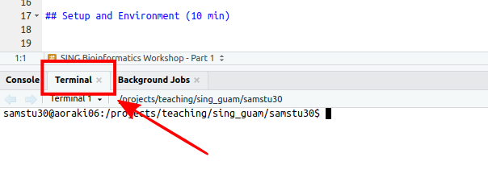

2. type the following into the `Terminal`

```bash
cd sing_guam
source load_software.sh
```

### What is the 1000 Genomes Project

The 1000 Genomes Project was an international consortium that was established in 2007 to provide a comprehensive record of human genetic variation. The project consisted of three main data phases. A pilot phase that whole-genome sequenced 179 individuals from four populations at low coverage (2-4x), along with high coverage sequencing for two trios (mother, father, and child), and exon targeted sequencing for 697 individuals from seven populations (1000 Genomes Project Consortium, 2010). The second main data phase provided sequencing data for 1092 individuals from 14 populations. This sequencing data set was a combination of low coverage whole-genome and exon sequencing (1000 Genomes Project Consortium, 2012). The third main phase (Phase 3) was a dataset consisting of low coverage whole-genome sequencing, deep exome sequencing, and dense SNP array genotyping for 2504 individuals from 26 populations (1000 Genomes Project Consortium, 2015). The 1000 Genomes data set used in this workshop is from the Phase 3 release, and is publicly available from https://ftp.1000genomes.ebi.ac.uk/vol1/ftp/phase3/data/.

The below shows the names of the sample populations, and their location.

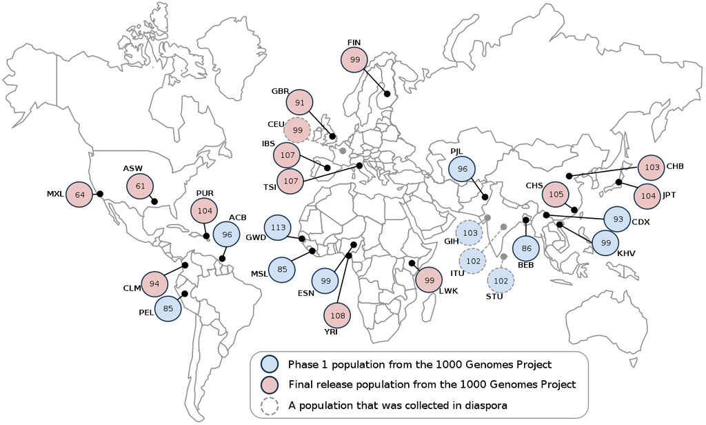

1000 Genomes Sample Populations. By Taras K. Oleksyk, Vladimir Brukhin and Stephen J. O’Brien - Oleksyk TK, Brukhin V, O’Brien SJ. The Genome Russia project: closing the largest remaining omission on the world Genome map. GigaScience. 2015;4:53. doi:10.1186/s13742-015-0095-0. https://gigascience.biomedcentral.com/articles/10.1186/s13742-015-0095-0, CC BY 4.0, https://commons.wikimedia.org/w/index.php?curid=56695551

We’re going to make use of a small subset of this data to show examples of some data types and bioinformatic analyses that can be done.

## From the sequencer to analysis-ready data (10 min)

The data file that comes out of the sequencer will look like this:

> @HWI-M01237:20:000000000-A5R87:1:1101:15995:1759 1:N:0:CCTAGGT

> TCTGAGGAGCTCTAATAACAAGCTCCATCTGCCTACGT CAAACCGACTTAAAAGCACTCAAGATCGGAAGTGCA…

> +HWI-M01237:20:000000000-A5R87:1:1101:15995:1759 1:N:0:CCTAGGT

> FFFFBD?11GGGGCGGB3B110AFGC1FFH1EAF1B0B A0/1AA//AAE1111101ABB0111ABA///?1B12…

We can have a quick look at these files:

```bash
cd ~/sing_guam/fastq/
less -S example.R1.fastq
```

When you’re done exploring, you can exit the viewer by pressing the `Q` key.

The file contain strings of DNA base pairs, identifiers, and encoded information about the quality of the sequencing run. The raw data undergoes quite a bit of processing before it can be used for analysis. The general pipeline looks like this:

1. First, the quality of the data is assessed to check see how well the sequencing went and how much we can trust the sequencer’s calls.
2. This can also include trimming of low-quality sequences or adapters (base pairs attached to the target DNA to aid in sequencing).
3. You might end up sequencing “off-target” portions of DNA – these can be identified and/or removed by comparing your sequences to a large database.
4. The sequence data is mapped to a reference.
5. Some intermediary steps are performed like removing duplicate sequences, sorting, and indexing.
6. In areas where many reads are mapped and genetic variation is present, variants are called. These may be variation at a single base pair (SNP), or across many base pairs (structural variation).
7. Variants are filtered and checked for quality, and possibly annotated and classified.
8. Further analysis can now take place.

The pipeline can be represented in the figure below:

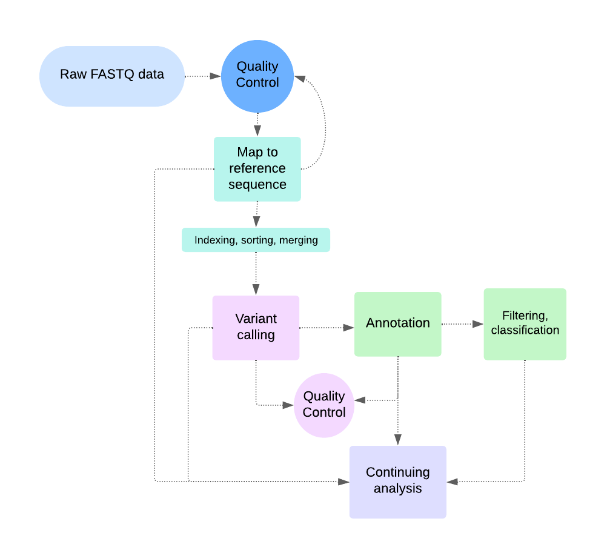

### Fastq format

A fastq file contains the sequencing reads. Groups of 4 lines constitute a read. For a full description of the format see https://en.wikipedia.org/wiki/FASTQ_format

1. Starts with `@`, contains read meta data - often sequencing machine information
2. read bases
3. line starts `+` often rest is empty but can be used for more metea data
4. base quality scores - encoded phred score (https://en.wikipedia.org/wiki/Phred_quality_score)

```bash
cd ~/sing_guam/fastq/
less -S example.R1.fastq
```

To exit less use the `Q` key.

We can use tools such as Fastqc to summarise the quality of our sequencing

```bash
fastqc example.R1.fastq example.R2.fastq
```

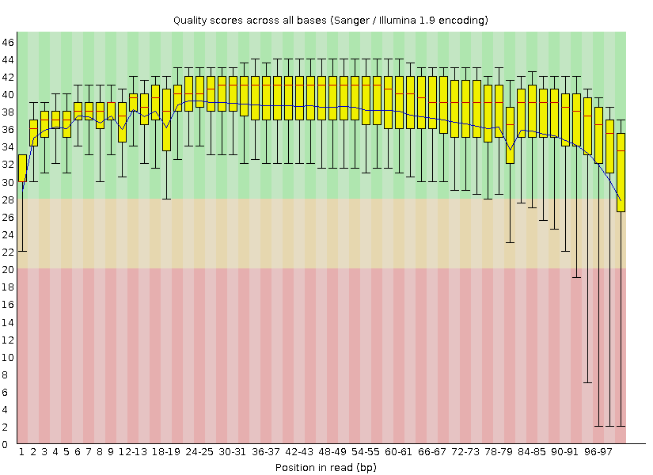

Example fastqc base quality output

**Quality Control**

The above image demonstrates a very common trend where the further into the sequence, the lower the quality of the data becomes. Additional quality control steps (such as trimming of reads) may be necessary to remove poor quality data.

## Aligning reads (15-20min)

Once we have reads from our sequencer of choice, we want to have an idea about where they come from in the genome. To do this we need to have the genome sequence - in our case this will be what is known as the human reference genome - while it is called a “reference”, it does not represent the full diversity of variation found in humans but enables us to *align* our sequencing reads by looking for regions in the reference that match (with some tolerance) to the sequence of our reads. We use alignment over genome assembly if we have access to a good enough genomic sequence, as assembly is a very computationally intensive process.

Let’s take a closer look at how some portions of the pipeline will look from the bioinformatic perspective. We can begin by aligning some reads from the sequencer –we will align a subset of reads to a gene called *ABCG2*. This is a gene on the fourth human chromosome that creates a protein involved in transport across cell membranes.

The tool we use for aligning is the *burrows-wheeler aligner* or `bwa`. It takes the fastq files and finds the best match of each read to the reference sequence, and then outputs a file that has read information from the fastq files. The file also includes where in the genome the read mapped to, plus how well it mapped/matched. This is stored in a *sequence alignment map (SAM)* file (see https://en.wikipedia.org/wiki/SAM_(file_format). The more efficient compressed binary version is the *bam* file.

```bash
cd ~/sing_guam/aligned

bwa mem ../ref/human_g1k_v37.fasta ../fastq/example.R1.fastq ../fastqexample.R2.fastq > example.sam
```

After alignment, we can get some statistics about the mapping by using the `flagstat` argument to `samtools`

```bash
samtools flagstat example.sam
```

Let’s take a look at the output of mapping with a viewer:

`samtools tview example.sam`

You can navigate with the arrow keys, or press `g` to jump to a particular region.

We see that each read has been placed somewhere along the reference, and there is a lot of overlap at each position. However, there is some variation present- some reads have one or more base pairs that are different from the reference sequence. When we have enough confidence that the different base pair is not an artifact of the sequencing, we call a variant – that is, identify a SNP – at that position.

We can call variants along the entire genome to get a sense of how much variation is present in the sample(s) of interest. Unfortunately, we won’t have time to do any variant calling ourselves today, but you can see the logic of how this works here.

When you’re ready, exit the viewer by pressing the `Q` key.

We have chosen to use a gout associated variant - rs2231142 - which located inside the gene *ABCG2*, which encodes a urate transporter protein, expressed in the gut and kidney - we’ll learn more about this variant later but for now we have 3 samples so that you can see what the sequencing reads look like in homozygous reference, heterozygous, and homozygous alternative allele situations. Which will give you a feel for how variants are determined from sequence data.

For this variant we have either an G (reference) or T (Alternative)

This code will show you the homozygous reference example

```bash
samtools tview rs2231142_hom_ref_example.bam -p 4:89052323 ../ref/human_g1k_v37.fasta
```

This code will show you the heterozygous example

```bash
samtools tview rs2231142_het_example.bam -p 4:89052323 ../ref/human_g1k_v37.fasta
```

This code will show you the homozygous alternative example

```bash
samtools tview rs2231142_hom_alt_example.bam -p 4:89052323 ../ref/human_g1k_v37.fasta
```

## Variant calling (40min)

We aren’t going to do the actual variant calling stage in this workshop as there are many different programs that are often used to accomplish this and is usually a multi-step process. Samtools, GATK, and Freebayes are the most common varint callers. The simplest method is a “pileup” where for each position of the genome a statistical model is applied to determine the likelihood of the genotype based on the number of reads for each allele present.

### VCF (10min)

The most common output from these tools is the *Variant Call Format (VCF)* which is a file format (https://en.wikipedia.org/wiki/Variant_Call_Format) that is a summarisation of one or more aligned samples. The file has a head which contains metadata where each line starts with `##`. Following this, is the data where each row is a variant. This format has 8 main columns:

| Name | Description |
| --- | --- |
| CHROM | Chromosome |
| POS | Position/coordinate on the chromsome |
| ID | Often a variant identifier |
| REF | Reference allele at the position |
| ALT | Alternative allele(s) observed at the position |
| QUAL | Phred score as to likelihood of variant |
| INFO | Contains overview statistics |
| FORMAT | Describes order of fields found in each sample column |

Following these is a column per sample with the sample genotype and extra information at the sample level. Genotypes are represented as 0 = reference, 1 = alternate. For a diploid organism (such as humans) we get 0/0 for homozygous reference, 0/1 heterozygote, and 1/1 homozygous for the alternative allele.

It’s important to note that reference and alternative are purely in relation to what allele the reference genome contained and does not tell you anything about the commonality of the allele population-wise.

Instead we shall take a look at a VCF file that was made from the 3 example bams we just looked at but only for the position of the variant rs2231142.

```bash
cd ~/sing_guam/vcf

less example.3_sample.vcf
```

Use the up/down arrow keys to scroll through this file.

### Variants – what can we do with them? (20min)

Once you’ve mapped reads and called your variants, what does one do with them? How does one use this data? Let’s assume we’re working with human data in a medical genetics context. We’ve identified a variant that seems to be associated a particular clinical outcome. We might be interested to know what the allele frequency of this variant is (i.e., how common is it?) Let’s assess the frequency of a variant called rs2231142, which is located in the *ABCG2* gene we mapped earlier:

There are many online databases dedicated to recording genomic variation and providing more context or information about what is known about the variant. One such online database is [ensembl](https://ensembl.org). We can use this database to find out some more about our variant rs2231142 at [ensembl](https://ensembl.org). We’ll use the links below to find out more:

- [Genomic context](https://grch37.ensembl.org/Homo_sapiens/Location/View?db=core;r=4:89051823-89052823;v=rs2231142;vdb=variation;vf=253533488)
- [Variant info](https://grch37.ensembl.org/Homo_sapiens/Variation/Explore?r=4:89051823-89052823;v=rs2231142;vdb=variation;vf=253533488)
- [Population frequencies](https://grch37.ensembl.org/Homo_sapiens/Variation/Population?db=core;r=4:89051823-89052823;v=rs2231142;vdb=variation;vf=253533488)
- [Phenotypes](https://grch37.ensembl.org/Homo_sapiens/Variation/Phenotype?db=core;r=4:89051823-89052823;v=rs2231142;vdb=variation;vf=253533488)

### Haplotype tree prep (10 min)

Later on, we’ll create our own phylogenetic tree for a population in the database. While we’re looking through an example VCF, we’ll run a subsetting function on the 1000 Genomes data to just one population. Subsetting is commonly applied to VCFs - you can select certain individuals, population groups, or even regions of the genome.

Choose a population code from the table below and run the following in `Terminal`:

```bash
cd ~/sing_guam/vcf

grep "PEL" 1kgp-phase3-samples.txt | cut -f1 > samples-of-interest.txt
```

NB: change `PEL` to any of the codes listed in the table below to select a particular population:

<sup>Table from Diroma et al., 2014 BMC Genomics (https://doi.org/10.1186%2F1471-2164-15-S3-S2)</sup>

| ACB | African Caribbean in Barbados |
| --- | --- |
| ASW | African Ancestry in Southwest USA |
| CDX | Chinese Dai in Xishuangbanna, China |
| CEU | Utah residents with ancestry from northern and western Europe |
| CHB | Han Chinese in Beijing, China |
| CHS | Han Chinese South, China |
| CLM | Colombian in Medellin, Colombia |
| FIN | Finnish in Finland |
| GBR | British From England and Scotland, UK |
| GIH | Gujarati Indians in Houston, Texas, USA |
| IBS | Iberian populations in Spain |
| JPT | Japanese in Tokyo, Japan |
| KHV | Kinh in Ho Chi Minh City, Vietnam |
| LWK | Luhya in Webuye, Kenya |
| MXL | Mexican Ancestry in Los Angeles, California, USA |
| PEL | Peruvian in Lima, Peru |
| PUR | Puerto Rican in Puerto Rico |
| TSI | Toscani in Italia |
| YRI | Yoruba in Ibadan, Nigeria |

Again in `Terminal`, run the following:

```bash
cd ~/sing_guam/vcf

bcftools view --samples-file samples-of-interest.txt --output pop.chrMT.vcf.gz 1kgp.chrMT.vcf.gz
```

```bash
less 1kgp.chrMT.vcf.gz
```

## Nanopore break (10/15 min)

# Appendix

## BASH quick reference

Navigation

- `pwd` tells you where you are in the file system
- `ls` will show you the names of files and directories where you are
  - `ls -F` will append a `/` onto the end of the names that are directories
- `cd` by itself will take you back to your home directory (`~/`)
- `cd directory_name` will place you in that directory, e.g `cd ~/sing_guam` will move you to the workshop area if you got mis-placed
- `./` infront of a file or directory means bash will look in the current directory (that shown by `pwd`)
- `../` infront of a file or directory means the parent directory (look one directory “up”), `../../` means look “2-up”, etc.
- `TAB` for completing program and file names. As you are typing make frequent use of hitting the `TAB` key as it will try to auto-complete file names/paths which will prevent typos.

Other utilities:

- `grep` is a commandline program that can search for patters in files
- `cut` lets you choose which columns you want to include from a file by adding `-f <column numbers>`

For more on BASH, take a looke at https://swcarpentry.github.io/shell-novice/